# Projet-9.2 Analyse

Moty Philippe

06-2022

# Import des données

```r
donnees.Pays <- read.csv("D:/IT/DATA/OC/DATA-PROJETS/PROJET-9/assets/data/data_pays_5.csv",sep=',',encoding='UTF-8')
rownames(donnees.Pays) = donnees.Pays$Country # index
```

# Classification Ascendante Hiérarchique

## Préparation des données

Data : les données sont est centrées réduites et nom pays comme index

```r
data <- donnees.Pays[,-1]
# Centrer et réduire les valeurs
data <- scale(data,center=TRUE, scale = TRUE)
```

## Clustering Ascendant hiérarchique

```r
# Classification ascendante hiérarchie
cah.res <- hclust(dist(data, method = 'euclidean' ),method='ward.D2')
```

## Dendrogramme

```r
# dendrogramme exporté en png
png(file="../assets/resultats/cah_dendrogramme.png",width=1800,height=750)
par(cex=0.8, mar=c(5, 8, 4, 1))
plot(cah.res, xlab="", ylab="", main="", hang = -1)
par(cex=2)
title(xlab="Pays", ylab="Distance", main="Classification ascendante hiérarchique ")
dev.off()
```

### Partition

```r
arbre <- cah.res
plot(arbre, labels = FALSE, main = "Partition en 5 ou 6 classes", xlab = "", ylab = "", sub = "", axes = FALSE, hang = -1)
rect.hclust(arbre, 5, border = "red3")
```

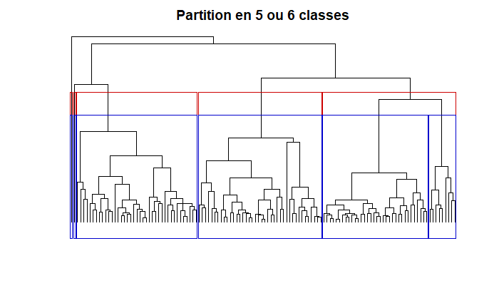

```r
rect.hclust(arbre, 6, border = "blue3")
```

#### Perte d’inertie

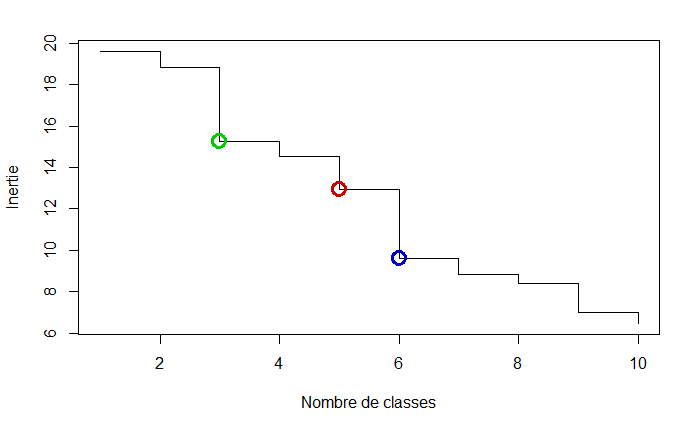

```r
inertie <- sort(arbre$height, decreasing = TRUE)
plot(inertie[1:10], type = "s", xlab = "Nombre de classes", ylab = "Inertie")

points(c(3, 5, 6), inertie[c(3, 5, 6)], col = c("green3", "red3", "blue3"), cex = 2, lwd = 3)
```

Pour obtenir une partition de la population (Pays), il suffit de découper le dendrogramme obtenu à une certaine hauteur. En premier lieu, une analyse de la forme du dendrogramme pourra nous donner une indication sur le nombre de classes à retenir. Dans notre exemple, deux branches bien distinctes apparaissent sur l’arbre.

Pour nous aider, nous pouvons représenter les sauts d’inertie du dendrogramme selon le nombre de classes retenues. On voit 3 saut assez nets à 3,5,6 représenté en vert, rouge, bleu

```r
png(file="../assets/resultats/cah_dendrogramme_2.png",width=1800,height=750)
fviz_dend(arbre, k = 6, show_labels = TRUE, rect = TRUE)
```

```r
rm(inertie,arbre)
```

### On détermine le nombre optimal de cluster

```r
# Détecter le nombre de cluster

BT <- c()
for (k in 1:10){
  tmp <-kmeans(data,centers=k)
  BT[k] <- tmp$betweenss/tmp$totss
} #je fais évoluer le nombre de cluster de 1 à 10

# affichage
print(BT)
```

```
 [1] -1.232378e-15  1.874650e-01  2.898463e-01  3.341091e-01  5.338315e-01  5.408632e-01
 [7]  5.998152e-01  6.818384e-01  7.280972e-01  6.622443e-01
```

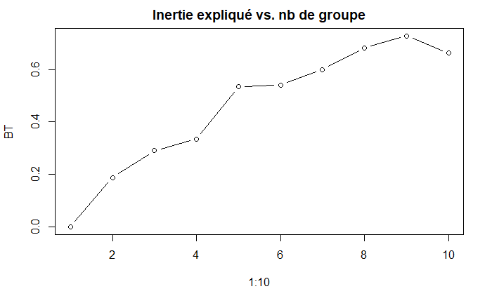

```r
# choix sur graphique
plot(1:10,BT,type='b',main='Inertie expliqué vs. nb de groupe')
```

```r
NA
```

```r
# on nettoie l'environnement
rm(BT, k, tmp)
```

### Coefficient de Silhouette pour déterminer la valeur optimale de k

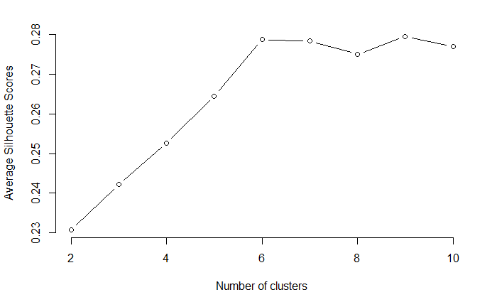

```r
silhouette_score <- function(k){
  km <- kmeans(data, centers = k, nstart=25)
  ss <- silhouette(km$cluster, dist(data))
  mean(ss[, 3])
}

k <- 2:10
avg_sil <- sapply(k, silhouette_score)
plot(k, type='b', avg_sil, xlab='Number of clusters', ylab='Average Silhouette Scores', frame=FALSE)
```

```r
# On nettoie l'environnement
rm(avg_sil,k,silhouette_score)
```

On choisit le nombre de cluster a 6

```r
cah.groupes = factor(cutree(cah.res, 6))
```

### On calcul des centroïdes

```r
centroides = data.frame() # on créé un df vide

# pour chaque groupes,
nom_groupes = unique(cah.groupes)
for (i in nom_groupes) {
  # je recupere les valeurs du cluster
  groupe = subset(data, cah.groupes == i)
  # je calcule le centroide en faisant une moyenne par colonne
  centroid = colMeans(groupe, na.rm = TRUE)
  # je l'ajoute au df
  centroides = rbind(centroides, centroid)
}

# on renomme chaque colonne avec le nom du dernier centroide calculé
names(centroides) = names(centroid)
rownames(centroides) = nom_groupes
```

## Visualisation heatmap de la classification hiérarchique

```r
centroides
```

|  | Production_MT | Importation_MT | PIB_US_._M | Political_stability | inflation_moy | pop_2017 | part_protein_Volaille.total | distance_France | Ease_of_doing_business_score |
| --- | --- | --- | --- | --- | --- | --- | --- | --- | --- |
| 1 | -0.21089558 | -0.25937503 | -0.21857702 | -0.9446069 | 0.7670981 | -0.03622749 | -0.665268197 | 0.001722823 | -1.02381603 |
| 2 | -0.11417166 | -0.09235679 | -0.07262193 | 0.6342448 | -0.2995822 | -0.19379183 | 0.004193859 | -0.985626633 | 0.98462761 |
| 3 | -0.02665602 | -0.35898430 | -0.18150403 | 0.3153550 | -0.3929703 | -0.14931954 | 0.563361374 | 0.930997805 | -0.06652401 |
| 4 | 0.35985213 | 3.10763666 | 0.77458842 | 0.3320566 | -0.3122720 | 0.18832744 | 0.315518196 | -0.461421850 | 0.88099805 |
| 5 | 1.16548561 | -0.49042694 | 1.14068979 | -0.7817941 | -0.4417918 | 10.07291128 | -1.139712947 | 0.281131837 | -0.50278588 |
| 6 | 8.76884994 | 0.13682603 | 10.14182509 | 0.4544303 | -0.7599806 | 2.20671764 | 1.568462684 | 0.075868039 | 1.68625020 |

```r
library(pheatmap)
```

```r
png(file="../assets/resultats/cah_pheatmaps.png",width=1800,height=750)
pheatmap(t(centroides),
         display_numbers = TRUE,# pour afficher les valeurs
         fontsize = 30, # pour diminuer la police des valeurs
         cluster_cols = FALSE,# pour obtenir un réarrangement de colonnes
         cluster_rows = FALSE, # pour obtenir un réarrangement de lignes
         scale="column"
         )
```

```r
round(centroides,2)
```

|  | Production_MT | Importation_MT | PIB_US_._M | Political_stability | inflation_moy | pop_2017 | part_protein_Volaille.total | distance_France | Ease_of_doing_business_score |
| --- | --- | --- | --- | --- | --- | --- | --- | --- | --- |
| 1 | -0.21 | -0.26 | -0.22 | -0.94 | 0.77 | -0.04 | -0.67 | 0.00 | -1.02 |
| 2 | -0.11 | -0.09 | -0.07 | 0.63 | -0.30 | -0.19 | 0.00 | -0.99 | 0.98 |
| 3 | -0.03 | -0.36 | -0.18 | 0.32 | -0.39 | -0.15 | 0.56 | 0.93 | -0.07 |
| 4 | 0.36 | 3.11 | 0.77 | 0.33 | -0.31 | 0.19 | 0.32 | -0.46 | 0.88 |
| 5 | 1.17 | -0.49 | 1.14 | -0.78 | -0.44 | 10.07 | -1.14 | 0.28 | -0.50 |
| 6 | 8.77 | 0.14 | 10.14 | 0.45 | -0.76 | 2.21 | 1.57 | 0.08 | 1.69 |

```r
png(file="../assets/resultats/cah_heatmap.png",width=1800,height=750)
heatmap(t(as.matrix(centroides)), Rowv = NA, Colv = NA, margins = c(6,6),main="clustering CAH")

legend(x="left",y='center',title = "Performance des clusters", legend=c("max","strong","medium","weak", "min"),cex=2,fill = heat.colors(6))
```

Ajouter une colonne cluster cah à data

```r
data_cah <- cbind(data, cah.groupes)
donnees.Pays <- cbind(donnees.Pays,cah.groupes)
# head(data)
```

```r
rm(nom_groupes,i,groupe,centroid,cah.res)

# export centroides
write.table(centroides,"../assets/resultats/cah_centroides.csv",sep=",",row.names=FALSE,quote=FALSE)
```

## Travail sur les pays

```r
temp <- subset(donnees.Pays, donnees.Pays$cah.groupes== 1)
print(temp$Country)
```

```
 [1] "Afghanistan"   "Algeria"       "Angola"        "Argentina"     "Azerbaijan"
 [6] "Bangladesh"    "Benin"         "Burkina Faso"  "Cameroon"      "Chad"
[11] "Ethiopia"      "Gabon"         "Gambia"        "Ghana"         "Guatemala"
[16] "Guinea"        "Guinea-Bissau" "Haiti"         "Iraq"          "Kenya"
[21] "Lebanon"       "Liberia"       "Madagascar"    "Mali"          "Mauritania"
[26] "Mozambique"    "Myanmar"       "Niger"         "Nigeria"       "Pakistan"
[31] "Rwanda"        "Sierra Leone"  "Sri Lanka"     "Sudan"         "Suriname"
[36] "Tajikistan"    "Togo"          "Uganda"        "Ukraine"
```

```r
temp <- subset(donnees.Pays, donnees.Pays$cah.groupes== 2)
print(temp$Country)
```

```
 [1] "Albania"                "Armenia"                "Austria"
 [4] "Belarus"                "Bosnia and Herzegovina" "Bulgaria"
 [7] "Canada"                 "Croatia"                "Cyprus"
[10] "Czechia"                "Denmark"                "Estonia"
[13] "Finland"                "Georgia"                "Greece"
[16] "Hungary"                "Ireland"                "Italy"
[19] "Kazakhstan"             "Latvia"                 "Lithuania"
[22] "Luxembourg"             "Malta"                  "Morocco"
[25] "Norway"                 "Poland"                 "Portugal"
[28] "Russian Federation"     "Slovenia"               "Spain"
[31] "Sweden"                 "Switzerland"            "Tunisia"
[34] "United Arab Emirates"
```

```r
temp <- subset(donnees.Pays, donnees.Pays$cah.groupes== 3)
print(temp$Country)
```

```
 [1] "Antigua and Barbuda" "Bahamas"             "Botswana"            "Brazil"
 [5] "Cambodia"            "Chile"               "Colombia"            "Costa Rica"
 [9] "Dominica"            "Dominican Republic"  "Ecuador"             "El Salvador"
[13] "Fiji"                "Grenada"             "Honduras"            "Indonesia"
[17] "Israel"              "Jamaica"             "Jordan"              "Kiribati"
[21] "Kuwait"              "Lesotho"             "Malaysia"            "Maldives"
[25] "Mauritius"           "Mongolia"            "Namibia"             "Nepal"
[29] "Nicaragua"           "Oman"                "Panama"              "Paraguay"
[33] "Peru"                "Samoa"               "Thailand"            "Trinidad and Tobago"
[37] "Uruguay"             "Vanuatu"             "Zambia"              "Zimbabwe"
```

```r
temp <- subset(donnees.Pays, donnees.Pays$cah.groupes== 4)
print(temp$Country)
```

```
[1] "Belgium"        "France"         "Germany"        "Japan"          "Mexico"
[6] "Netherlands"    "Saudi Arabia"   "South Africa"   "United Kingdom"
```

```r
temp <- subset(donnees.Pays, donnees.Pays$cah.groupes== 5)
print(temp$Country)
```

```
[1] "India"
```

```r
temp <- subset(donnees.Pays, donnees.Pays$cah.groupes== 6)
print(temp$Country)
```

```
[1] "United States of America"
```

### MAP - Clustering CAH

Préparation des données

```r
# donnee.map <- donnees.Pays
# donnee.map <- c("Country","cah.groupes")
# donnee.map <- as.data.frame(donnee.map)
```

```r
png(file="../assets/resultats/cah_map.png",width=1800,height=750)
country_colors <- setNames(rep("white", length(my_map$NAME)), my_map$NAME)

country_colors[c("Afghanistan","Algeria","Angola","Argentina","Azerbaijan","Bangladesh","Burkina Faso","Cameroon","Chad","Ethiopia","Gabon","Gambia","Guatemala","Guinea","Guinea-Bissau","Haiti","Iraq","Kenya","Lebanon","Liberia","Madagascar","Mali","Mauritania","Mozambique","Myanmar","Niger","Nigeria","Pakistan","Rwanda","Sierra Leone","Sri Lanka","Sudan","Suriname","Tajikistan","Togo")] <- c("yellow") # cluster 1


country_colors[c( "Albania","Armenia","Austria","Belarus","Bosnia and Herzegovina","Canada","Croatia","Cyprus","Czech Republic","Denmark","Estonia","Finland" , "Georgia","Greece","Hungary","Ireland","Italy"  ,"Kazakhstan","Latvia","Lithuania", "Luxembourg","Malta","Morocco","Norway","Poland","Portugal","Russia","Slovenia", "Spain","Sweden","Switzerland","Tunisia","Ukraine","United Arab Emirates")] <- c("pink") # cluster 2


country_colors[c("Antigua and Barbuda","Bahamas","Benin","Botswana","Brazil"  ,"Cambodia","Chile"   ,"Colombia","Costa Rica","Dominica","Dominican Republic","Ecuador","El Salvador","Fiji","Ghana","Grenada","Honduras","Indonesia","Israel", "Jamaica","Jordan","Kiribati","Kuwait","Lesotho", "Malaysia","Maldives","Mauritius","Mongolia","Nepal","Nicaragua","Oman","Panama", "Paraguay","Peru","Samoa","Thailand","Trinidad and Tobago", "Uruguay","Vanuatu","Zambia","Zimbabwe")] <- c("green") # cluster 3

country_colors[c( "Belgium","France","Germany","Japan","Mexico","Netherlands","Saudi Arabia", "South Africa","United Kingdom")] <- c("red") # cluster4

country_colors[c( "India")] <- c("blue") # cluster 5

country_colors[c( "United States")] <- c("orange") # cluster 6

plot(my_map, col = country_colors)
title("Resultat clustering par CAH")

legend(x='bottomright', border = "black",title = 'les clusters',cex=2 ,legend = c( "cluster 1", "cluster 2", "cluster 3", "cluster 4", "cluster 5", "cluster 6"),fill = c('yellow','pink','green','red','blue','orange'))
```

Nettoyage environnement

```r
rm(wrld_simpl,temp,my_map,country_colors,centroides,data_cah,cah.groupes)
```

# K-MEANS

## On détermine le nombre optimal de cluster

création de la fonction

```r
# WWS plot function
wss <- function(data, nc=10, seed=1234) {
  wss <- (nrow(data)-1)*sum(apply(data,2,var))
  for (i in 2:nc) {
    set.seed(seed)
    wss[i] <- sum(kmeans(data,centers=i)$withinss)}

plot(1:nc,wss,type="b", xlab="Number of Clusters", ylab="Within groups sum of square")
}
```

## On affiche le plot de la méthode du coude

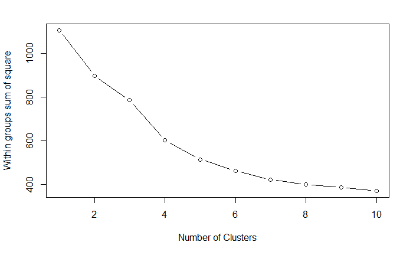

```r
wss(data)
```

```r
# On nettoie l'environnement
rm(wss)
```

## On compare

```r
ratio_ss <- data.frame(cluster = seq(from = 1, to = 9, by = 1))
for (k in 1:9) {
km_model <- kmeans(data, k, nstart = 20)
ratio_ss$ratio[k] <- km_model$tot.withinss / km_model$totss
}
```

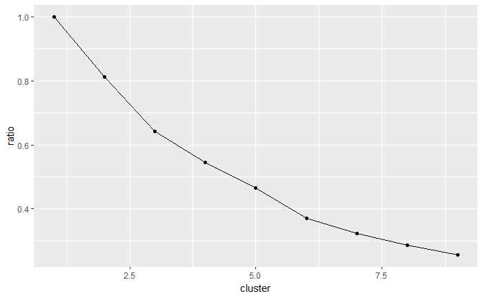

```r
ggplot(ratio_ss, aes(cluster, ratio)) +
geom_line() +
geom_point()
```

## Calcule du 6-Means

```r
# Compute k-means with k = 6
km.res <- kmeans(data, 6, nstart = 25)
```

Afficher le resultat

```r
print(km.res)
```

```
K-means clustering with 6 clusters of sizes 12, 32, 37, 1, 41, 1

Cluster means:
  Production_MT Importation_MT PIB_US_._M Political_stability inflation_moy    pop_2017
1   -0.16486514     -0.2660438 -0.1922927          -0.8023979     2.4386819 -0.01172392
2    0.03066207     -0.2628565 -0.1763625           0.3655767    -0.4630001 -0.17976759
3   -0.21940238     -0.3160752 -0.2210539          -0.7878689     0.0222644 -0.04343068
4    1.16548561     -0.4904269  1.1406898          -0.7817941    -0.4417918 10.07291128
5   -0.01998175      0.5768857  0.1182340           0.6685082    -0.3431753 -0.11657180
6    8.76884994      0.1368260 10.1418251           0.4544303    -0.7599806  2.20671764
  part_protein_Volaille.total distance_France Ease_of_doing_business_score
1                 -0.54938333      0.09657515                  -0.69069887
2                  1.03241706      0.94945017                  -0.03159618
3                 -0.78555607      0.13773837                  -0.88373854
4                 -1.13971295      0.28113184                  -0.50278588
5                  0.05346534     -0.90230797                   0.99547136
6                  1.56846268      0.07586804                   1.68625020

Clustering vector:
             Afghanistan                  Albania                  Algeria
                       3                        5                        3
                  Angola      Antigua and Barbuda                Argentina
                       1                        2                        1
                 Armenia                  Austria               Azerbaijan
                       3                        5                        1
                 Bahamas               Bangladesh                  Belarus
                       2                        3                        5
                 Belgium                    Benin   Bosnia and Herzegovina
                       5                        3                        5
                Botswana                   Brazil                 Bulgaria
                       2                        2                        5
            Burkina Faso                 Cambodia                 Cameroon
                       3                        3                        3
                  Canada                     Chad                    Chile
                       5                        3                        2
                Colombia               Costa Rica                  Croatia
                       2                        2                        5
                  Cyprus                  Czechia                  Denmark
                       5                        5                        5
                Dominica       Dominican Republic                  Ecuador
```

[output cut: 57 more lines]

```
    United Arab Emirates           United Kingdom United States of America
                       5                        5                        6
                 Uruguay                  Vanuatu                   Zambia
                       2                        2                        3
                Zimbabwe
                       3

Within cluster sum of squares by cluster:
[1]  51.00111 133.93371  97.66060   0.00000 163.46491   0.00000
 (between_SS / total_SS =  59.7 %)

Available components:

[1] "cluster"      "centers"      "totss"        "withinss"     "tot.withinss" "betweenss"
[7] "size"         "iter"         "ifault"
```

Il est possible de calculer la moyenne de chaque variable par clusters en utilisant les données d’origine :

```r
agg_donneesPays_cluster <- aggregate(donnees.Pays, by=list(cluster=km.res$cluster), mean)
agg_donneesPays_cluster <- agg_donneesPays_cluster[,c(-2,-12)]
```

```r
# export centroides des clusters
write.table(agg_donneesPays_cluster,"../assets/resultats/km6_centroides.csv",sep=",",row.names=FALSE,quote=FALSE)
```

Ajouter les classifications de points aux données d’origine :

```r
donnees.Pays <- cbind(donnees.Pays, cluster = km.res$cluster)
head(donnees.Pays)
```

|  | Country | Production_MT | Importation_MT | PIB_US_._M | Political_stability | inflation_moy | pop_2017 | part_protein_Volaille.total | distance_France | Ease_of_doing_business_score | cah.groupes | cluster |
| --- | --- | --- | --- | --- | --- | --- | --- | --- | --- | --- | --- | --- |
| Afghanistan | Afghanistan | 28 | 29 | 18896.352 | -2.80 | 6.957529 | 36296113 | 1.06 | 5590.381 | 39.23702 | 1 | 3 |
| Albania | Albania | 13 | 38 | 13019.730 | 0.38 | 4.135979 | 2884169 | 3.87 | 1603.534 | 63.98701 | 2 | 5 |
| Algeria | Algeria | 275 | 2 | 170096.984 | -0.92 | 5.040496 | 41389189 | 2.40 | 1340.390 | 45.79658 | 1 | 3 |
| Angola | Angola | 42 | 277 | 122123.859 | -0.33 | 28.911962 | 29816766 | 6.77 | 6510.322 | 37.19322 | 1 | 1 |
| Antigua and Barbuda | Antigua and Barbuda | 0 | 7 | 1467.978 | 0.75 | 1.874554 | 95426 | 23.31 | 6708.770 | 58.44521 | 3 | 2 |
| Argentina | Argentina | 2161 | 8 | 643628.396 | 0.17 | 17.671433 | 43937140 | 13.54 | 11072.250 | 57.90516 | 1 | 1 |

```r
centroides = km.res$centers
centroides <- centroides[,-10]
png(file="../assets/resultats/km6_heatmap.png",width=1800,height=750)
heatmap(t(as.matrix(centroides)), Rowv = NA, Colv = NA, margins = c(6,6),main="Clustering 6-means")
legend(x="left",y='center',title = "Performance des clusters", legend=c("max","strong","medium","weak", "min"),cex=2,fill = heat.colors(6))
```

```r
png(file="../assets/resultats/km6_pheatmaps.png",width=1800,height=750)
pheatmap(t(centroides),
         display_numbers = TRUE,# pour afficher les valeurs
         fontsize = 30, # pour diminuer la police des valeurs
         cluster_cols = FALSE,# pour obtenir un réarrangement de colonnes
         cluster_rows = FALSE, # pour obtenir un réarrangement de lignes
         scale="column"
         )
```

## Etude des pays

```r
temp <- subset(donnees.Pays, donnees.Pays$cluster== 1)
print(temp$Country)
```

```
 [1] "Angola"       "Argentina"    "Azerbaijan"   "Guinea"       "Kenya"        "Mozambique"
 [7] "Nigeria"      "Rwanda"       "Sierra Leone" "Sudan"        "Suriname"     "Ukraine"
```

```r
temp <- subset(donnees.Pays, donnees.Pays$cluster== 2)
print(temp$Country)
```

```
 [1] "Antigua and Barbuda" "Bahamas"             "Botswana"            "Brazil"
 [5] "Chile"               "Colombia"            "Costa Rica"          "Dominica"
 [9] "Dominican Republic"  "Ecuador"             "El Salvador"         "Fiji"
[13] "Gabon"               "Grenada"             "Honduras"            "Israel"
[17] "Jamaica"             "Jordan"              "Kiribati"            "Kuwait"
[21] "Malaysia"            "Mauritius"           "Namibia"             "Nicaragua"
[25] "Panama"              "Peru"                "Samoa"               "South Africa"
[29] "Thailand"            "Trinidad and Tobago" "Uruguay"             "Vanuatu"
```

```r
temp <- subset(donnees.Pays, donnees.Pays$cluster== 3)
print(temp$Country)
```

```
 [1] "Afghanistan"   "Algeria"       "Armenia"       "Bangladesh"    "Benin"
 [6] "Burkina Faso"  "Cambodia"      "Cameroon"      "Chad"          "Ethiopia"
[11] "Gambia"        "Ghana"         "Guatemala"     "Guinea-Bissau" "Haiti"
[16] "Indonesia"     "Iraq"          "Lebanon"       "Lesotho"       "Liberia"
[21] "Madagascar"    "Maldives"      "Mali"          "Mauritania"    "Mongolia"
[26] "Myanmar"       "Nepal"         "Niger"         "Pakistan"      "Paraguay"
[31] "Sri Lanka"     "Tajikistan"    "Togo"          "Tunisia"       "Uganda"
[36] "Zambia"        "Zimbabwe"
```

```r
temp <- subset(donnees.Pays, donnees.Pays$cluster== 4)
print(temp$Country)
```

```
[1] "India"
```

```r
temp <- subset(donnees.Pays, donnees.Pays$cluster== 5)
print(temp$Country)
```

```
 [1] "Albania"                "Austria"                "Belarus"
 [4] "Belgium"                "Bosnia and Herzegovina" "Bulgaria"
 [7] "Canada"                 "Croatia"                "Cyprus"
[10] "Czechia"                "Denmark"                "Estonia"
[13] "Finland"                "France"                 "Georgia"
[16] "Germany"                "Greece"                 "Hungary"
[19] "Ireland"                "Italy"                  "Japan"
[22] "Kazakhstan"             "Latvia"                 "Lithuania"
[25] "Luxembourg"             "Malta"                  "Mexico"
[28] "Morocco"                "Netherlands"            "Norway"
[31] "Oman"                   "Poland"                 "Portugal"
[34] "Russian Federation"     "Saudi Arabia"           "Slovenia"
[37] "Spain"                  "Sweden"                 "Switzerland"
[40] "United Arab Emirates"   "United Kingdom"
```

```r
temp <- subset(donnees.Pays, donnees.Pays$cluster == 6)
print(temp$Country)
```

```
[1] "United States of America"
```

### Carte repartition des groupes issus du 6-means

```r
#library(maptools)
data(wrld_simpl)
my_map <- wrld_simpl
```

```r
png(file="../assets/resultats/km6_map.png",width=1800,height=750)
country_colors <- setNames(rep("white", length(my_map$NAME)), my_map$NAME)

country_colors[c("Angola","Argentina","Azerbaijan","Ethiopia","Guinea","Kenya","Mozambique","Nigeria","Rwanda","Sierra Leone","Sudan","Suriname","Ukraine")] <- c("yellow") # cluster 1

country_colors[c("Antigua and Barbuda","Bahamas","Brazil","Chile","Colombia","Costa Rica","Dominica","Dominican Republic","Fiji","Grenada","Israel","Jamaica","Japan","Kiribati","Kuwait","Malaysia","Mauritius","Mexico","Panama","Peru","Samoa","Saudi Arabia","South Africa","Trinidad and Tobago","Vanuatu"   )] <- c("pink") # cluster 2

country_colors[c(
  "Afghanistan",   "Algeria",       "Bangladesh",    "Benin",         "Botswana",      "Burkina Faso",  "Cambodia",
  "Cameroon",      "Chad",          "Ecuador",       "El Salvador",   "Gabon",         "Gambia",        "Ghana",
  "Guatemala",     "Guinea-Bissau", "Haiti",         "Honduras",      "Indonesia",     "Iraq",          "Jordan",
  "Lebanon",       "Lesotho",       "Liberia" ,      "Madagascar",    "Maldives",      "Mali",          "Mauritania",
  "Mongolia",      "Myanmar",       "Namibia",       "Nepal",         "Nicaragua",     "Niger",         "Pakistan",
  "Paraguay",      "Sri Lanka" ,    "Tajikistan",    "Thailand",      "Togo",          "Tunisia",       "Uganda",
  "Uruguay",       "Zambia",        "Zimbabwe"
  )] <- c("green") # cluster 3

country_colors[c("India")] <- c("red") # cluster4

country_colors[c(
  "Albania",                "Armenia",                "Austria",                "Belarus",
  "Belgium",                "Bosnia and Herzegovina", "Bulgaria",               "Canada",
  "Croatia",                "Cyprus",                 "Czech Republic",                "Denmark",
  "Estonia",                "Finland",                "France",                 "Georgia",
  "Germany",                "Greece",                 "Hungary" ,               "Ireland",
  "Italy" ,                 "Kazakhstan",             "Latvia",                 "Lithuania",
  "Luxembourg" ,            "Malta",                  "Morocco",                "Netherlands",
  "Norway",                 "Oman",                   "Poland",                 "Portugal",
  "Russia" ,               "Slovenia",               "Spain",                  "Sweden",
  "Switzerland",            "United Arab Emirates", "United Kingdom"
  )] <- c("blue") # cluster 5

country_colors[c("United States")] <- c('orange') # cluster 6

plot(my_map, col = country_colors)
title("Resultat clustering par K-MEANS")

legend(x='bottomright', border = "black",title = 'les clusters',cex=2 ,legend = c( "cluster 1", "cluster 2", "cluster 3", "cluster 4", "cluster 5", "cluster 6"),fill = c('yellow','pink','green','red','blue','orange'))
```

Nettoyage environnement

```r
rm(wrld_simpl,temp,my_map,km.res,country_colors,centroides,agg_donneesPays_cluster)
```

## K-Means a 5 pour conforter notre décisions à 6

Calcule du K-Means

```r
# Compute k-means with k = 5
km.res <- kmeans(data, 5, nstart = 25)
```

Afficher le resultat

```r
print(km.res)
```

```
K-means clustering with 5 clusters of sizes 1, 45, 43, 1, 34

Cluster means:
  Production_MT Importation_MT PIB_US_._M Political_stability inflation_moy    pop_2017
1    8.76884994      0.1368260 10.1418251           0.4544303    -0.7599806  2.20671764
2   -0.23867233     -0.2933551 -0.2298174          -0.8642091     0.6338936 -0.06499601
3   -0.03298713      0.5325801  0.1008912           0.6452218    -0.3296180 -0.12476202
4    1.16548561     -0.4904269  1.1406898          -0.7817941    -0.4417918 10.07291128
5    0.06542252     -0.2748931 -0.1552663           0.3374187    -0.3867607 -0.11735417
  part_protein_Volaille.total distance_France Ease_of_doing_business_score
1                  1.56846268      0.07586804                   1.68625020
2                 -0.75632090      0.07318941                  -0.92859765
3                  0.01086978     -0.86431720                   0.97160422
4                 -1.13971295      0.28113184                  -0.50278588
5                  0.97465560      0.98573872                  -0.03457505

Clustering vector:
             Afghanistan                  Albania                  Algeria
                       2                        3                        2
                  Angola      Antigua and Barbuda                Argentina
                       2                        5                        5
                 Armenia                  Austria               Azerbaijan
                       3                        3                        2
                 Bahamas               Bangladesh                  Belarus
                       5                        2                        3
                 Belgium                    Benin   Bosnia and Herzegovina
                       3                        2                        3
                Botswana                   Brazil                 Bulgaria
                       5                        5                        3
            Burkina Faso                 Cambodia                 Cameroon
                       2                        2                        2
                  Canada                     Chad                    Chile
                       3                        2                        5
                Colombia               Costa Rica                  Croatia
                       5                        5                        3
                  Cyprus                  Czechia                  Denmark
                       3                        3                        3
                Dominica       Dominican Republic                  Ecuador
                       5                        5                        5
             El Salvador                  Estonia                 Ethiopia
```

[output cut: 55 more lines]

```
    United Arab Emirates           United Kingdom United States of America
                       3                        3                        1
                 Uruguay                  Vanuatu                   Zambia
                       5                        5                        2
                Zimbabwe
                       2

Within cluster sum of squares by cluster:
[1]   0.0000 175.8000 171.7531   0.0000 149.4567
 (between_SS / total_SS =  55.1 %)

Available components:

[1] "cluster"      "centers"      "totss"        "withinss"     "tot.withinss" "betweenss"
[7] "size"         "iter"         "ifault"
```

```r
# df <- as.data.frame(km.res$cluster)
table(km.res$cluster)
```

```
 1  2  3  4  5
 1 45 43  1 34
```

Il est possible de calculer la moyenne de chaque variable par clusters en utilisant les données d’origine :

```r
agg_donneesPays_cluster <- aggregate(donnees.Pays, by=list(cluster=km.res$cluster), mean)
# agg_donneesPays_cluster <- agg_donneesPays_cluster[,c(-2,-12)]
```

```r
# export centroides des clusters
write.table(agg_donneesPays_cluster,"../assets/resultats/km5_centroides.csv",sep=",",row.names=FALSE,quote=FALSE)
```

Ajouter les classifications de points aux données d’origine :

```r
donnees.Pays <- cbind(donnees.Pays, cluster.km.5 = km.res$cluster)
head(donnees.Pays)
```

|  | Country | Production_MT | Importation_MT | PIB_US_._M | Political_stability | inflation_moy | pop_2017 | part_protein_Volaille.total | distance_France | Ease_of_doing_business_score | cah.groupes | cluster | cluster.km.5 |
| --- | --- | --- | --- | --- | --- | --- | --- | --- | --- | --- | --- | --- | --- |
| Afghanistan | Afghanistan | 28 | 29 | 18896.352 | -2.80 | 6.957529 | 36296113 | 1.06 | 5590.381 | 39.23702 | 1 | 3 | 2 |
| Albania | Albania | 13 | 38 | 13019.730 | 0.38 | 4.135979 | 2884169 | 3.87 | 1603.534 | 63.98701 | 2 | 5 | 3 |
| Algeria | Algeria | 275 | 2 | 170096.984 | -0.92 | 5.040496 | 41389189 | 2.40 | 1340.390 | 45.79658 | 1 | 3 | 2 |
| Angola | Angola | 42 | 277 | 122123.859 | -0.33 | 28.911962 | 29816766 | 6.77 | 6510.322 | 37.19322 | 1 | 1 | 2 |
| Antigua and Barbuda | Antigua and Barbuda | 0 | 7 | 1467.978 | 0.75 | 1.874554 | 95426 | 23.31 | 6708.770 | 58.44521 | 3 | 2 | 5 |
| Argentina | Argentina | 2161 | 8 | 643628.396 | 0.17 | 17.671433 | 43937140 | 13.54 | 11072.250 | 57.90516 | 1 | 1 | 5 |

```r
centroides = km.res$centers
centroides <- centroides[,-10]
png(file="../assets/resultats/km5_heatmap.png",width=1800,height=750)
heatmap(t(as.matrix(centroides)), Rowv = NA, Colv = NA, margins = c(6,6),main="Clustering K-means"
        )
legend(x="left",y='center',title = "Performance des clusters", legend=c("max","strong","medium","weak", "min"),cex=2,fill = heat.colors(6))
```

```r
png(file="../assets/resultats/km5_pheatmaps.png",width=1800,height=750)
pheatmap(t(centroides),
         display_numbers = TRUE,# pour afficher les valeurs
         fontsize = 30, # pour diminuer la police des valeurs
         cluster_cols = FALSE,# pour obtenir un réarrangement de colonnes
         cluster_rows = FALSE, # pour obtenir un réarrangement de lignes
         scale="column"
         )
```

ETUDE DES PAYS DES CLUSTERS CARTE

```r
temp <- subset(donnees.Pays, donnees.Pays$cluster.km.5== 1)
print(temp$Country)
```

```
[1] "United States of America"
```

```r
temp <- subset(donnees.Pays, donnees.Pays$cluster.km.5== 2)
print(temp$Country)
```

```
 [1] "Afghanistan"   "Algeria"       "Angola"        "Azerbaijan"    "Bangladesh"
 [6] "Benin"         "Burkina Faso"  "Cambodia"      "Cameroon"      "Chad"
[11] "Ethiopia"      "Gambia"        "Ghana"         "Guatemala"     "Guinea"
[16] "Guinea-Bissau" "Haiti"         "Iraq"          "Kenya"         "Lebanon"
[21] "Lesotho"       "Liberia"       "Madagascar"    "Maldives"      "Mali"
[26] "Mauritania"    "Mozambique"    "Myanmar"       "Nepal"         "Niger"
[31] "Nigeria"       "Pakistan"      "Paraguay"      "Rwanda"        "Sierra Leone"
[36] "Sri Lanka"     "Sudan"         "Suriname"      "Tajikistan"    "Togo"
[41] "Tunisia"       "Uganda"        "Ukraine"       "Zambia"        "Zimbabwe"
```

```r
temp <- subset(donnees.Pays, donnees.Pays$cluster.km.5== 3)
print(temp$Country)
```

```
 [1] "Albania"                "Armenia"                "Austria"
 [4] "Belarus"                "Belgium"                "Bosnia and Herzegovina"
 [7] "Bulgaria"               "Canada"                 "Croatia"
[10] "Cyprus"                 "Czechia"                "Denmark"
[13] "Estonia"                "Finland"                "France"
[16] "Georgia"                "Germany"                "Greece"
[19] "Hungary"                "Ireland"                "Italy"
[22] "Japan"                  "Kazakhstan"             "Latvia"
[25] "Lithuania"              "Luxembourg"             "Malta"
[28] "Mexico"                 "Mongolia"               "Morocco"
[31] "Netherlands"            "Norway"                 "Oman"
[34] "Poland"                 "Portugal"               "Russian Federation"
[37] "Saudi Arabia"           "Slovenia"               "Spain"
[40] "Sweden"                 "Switzerland"            "United Arab Emirates"
[43] "United Kingdom"
```

```r
temp <- subset(donnees.Pays, donnees.Pays$cluster.km.5== 4)
print(temp$Country)
```

```
[1] "India"
```

```r
temp <- subset(donnees.Pays, donnees.Pays$cluster.km.5== 5)
print(temp$Country)
```

```
 [1] "Antigua and Barbuda" "Argentina"           "Bahamas"             "Botswana"
 [5] "Brazil"              "Chile"               "Colombia"            "Costa Rica"
 [9] "Dominica"            "Dominican Republic"  "Ecuador"             "El Salvador"
[13] "Fiji"                "Gabon"               "Grenada"             "Honduras"
[17] "Indonesia"           "Israel"              "Jamaica"             "Jordan"
[21] "Kiribati"            "Kuwait"              "Malaysia"            "Mauritius"
[25] "Namibia"             "Nicaragua"           "Panama"              "Peru"
[29] "Samoa"               "South Africa"        "Thailand"            "Trinidad and Tobago"
[33] "Uruguay"             "Vanuatu"
```

### Carte repartition des groupes issus du kmeans

```r
#library(maptools)
data(wrld_simpl)
my_map <- wrld_simpl
```

```r
png(file="../assets/resultats/km5_map.png",width=1800,height=750)
country_colors <- setNames(rep("white", length(my_map$NAME)), my_map$NAME)

country_colors[c("United States")] <- c('orange') # cluster 1

country_colors[c("Afghanistan",   "Algeria",       "Angola" ,       "Azerbaijan",    "Bangladesh",    "Benin",         "Burkina, Faso","Cambodia",      "Cameroon",      "Chad" ,         "Ethiopia" ,     "Gambia",        "Ghana",         "Guatemala" ,   "Guinea",        "Guinea-Bissau", "Haiti" ,        "Iraq" ,         "Kenya",         "Lebanon",       "Lesotho",      "Liberia",       "Madagascar",    "Maldives",      "Mali" ,         "Mauritania",    "Mozambique",    "Myanmar",      "Nepal",         "Niger" ,        "Nigeria",       "Pakistan",      "Paraguay",      "Rwanda",        "Sierra Leone" ,"Sri Lanka",     "Sudan" ,        "Suriname",      "Tajikistan",    "Togo",          "Tunisia",      "Uganda",       "Ukraine",       "Zambia",        "Zimbabwe"  )] <- c("blue") # cluster 2

country_colors[c(
"Albania",                "Armenia",                "Austria",                "Belarus",
"Belgium",                "Bosnia and Herzegovina", "Bulgaria",               "Canada",
"Croatia" ,               "Cyprus",                 "Czech Republic",         "Denmark" ,
"Estonia",                "Finland",                "France",                 "Georgia",
"Germany",                "Greece",                 "Hungary",                "Ireland" ,
"Italy",                  "Japan",                  "Kazakhstan" ,            "Latvia",
"Lithuania" ,             "Luxembourg",             "Malta",                  "Mexico",
"Mongolia",               "Morocco",                "Netherlands",            "Norway",
"Oman",                   "Poland",                 "Portugal",               "Russia" ,
"Saudi Arabia",           "Slovenia",               "Spain",                  "Sweden",
"Switzerland","United Arab Emirates", "United Kingdom" )] <- c("yellow") # cluster 3

country_colors[c("India")] <- c("pink") # cluster 4

country_colors[c(
"Antigua and Barbuda", "Argentina" ,          "Bahamas",             "Botswana",            "Brazil",
"Chile" ,              "Colombia" ,           "Costa Rica",          "Dominica",            "Dominican Republic",
"Ecuador"   ,          "El Salvador" ,        "Fiji",                "Gabon",               "Grenada" ,
"Honduras"  ,          "Indonesia",           "Israel",              "Jamaica",             "Jordan",
"Kiribati"  ,          "Kuwait",              "Malaysia" ,           "Mauritius",           "Namibia",
"Nicaragua",           "Panama",              "Peru" ,               "Samoa",               "South Africa",
"Thailand"  ,          "Trinidad and Tobago", "Uruguay",             "Vanuatu"
)] <- c("green") # cluster 5



plot(my_map, col = country_colors)
title("Resultat clustering par 5-MEANS")

legend(x='bottomright', border = "black",title = 'les clusters',cex=2 ,legend = c( "cluster 1", "cluster 2", "cluster 3", "cluster 4", 'cluster 5'),fill = c('yellow','pink','green','red', "blue"))
```

Nettoyage environnement

```r
rm(wrld_simpl,temp,my_map,km.res,country_colors,centroides,agg_donneesPays_cluster,ratio_ss,km_model,k)
```

CHOIX CLUSTER ET ACP creer un df avec les pays du cluster kmeans 6 Kmeans est plus performant dans la définition de zones plus cohérantes : au niveau business (alliance, proximités, membre d’association éconnomique, distance…) k= 6 permet de filtrer un maximum de pays en restant cohérent

# ACP

Import des bibliothèques

```r
library("FactoMineR")
library("factoextra")
```

## Préparation des données

```r
str(donnees.Pays)
```

```
'data.frame':   124 obs. of  13 variables:
 $ Country                     : chr  "Afghanistan" "Albania" "Algeria" "Angola" ...
 $ Production_MT               : int  28 13 275 42 0 2161 11 148 104 6 ...
 $ Importation_MT              : int  29 38 2 277 7 8 35 110 27 24 ...
 $ PIB_US_._M                  : num  18896 13020 170097 122124 1468 ...
 $ Political_stability         : num  -2.8 0.38 -0.92 -0.33 0.75 0.17 -0.62 1.05 -0.75 0.99 ...
 $ inflation_moy               : num  6.96 4.14 5.04 28.91 1.87 ...
 $ pop_2017                    : int  36296113 2884169 41389189 29816766 95426 43937140 2944791 8819901 9845320 381755 ...
 $ part_protein_Volaille.total : num  1.06 3.87 2.4 6.77 23.31 ...
 $ distance_France             : num  5590 1604 1340 6510 6709 ...
 $ Ease_of_doing_business_score: num  39.2 64 45.8 37.2 58.4 ...
 $ cah.groupes                 : Factor w/ 6 levels "1","2","3","4",..: 1 2 1 1 3 1 2 2 1 3 ...
 $ cluster                     : int  3 5 3 1 2 1 3 5 1 2 ...
 $ cluster.km.5                : int  2 3 2 2 5 5 3 3 2 5 ...
```

```r
# On crée un df avec uniquement les données du 6-means = 5 en raison de sa cohérence et de la performance de ses indicateurs
donnees.pca <- donnees.Pays
donnees.pca <- subset(donnees.pca, donnees.pca$cluster == 5)

# on crée un df sans les colonnes de clustering
donnees.pca <- donnees.pca[,2:10]
```

## Visualisation de l’ACP

Standardisation des données

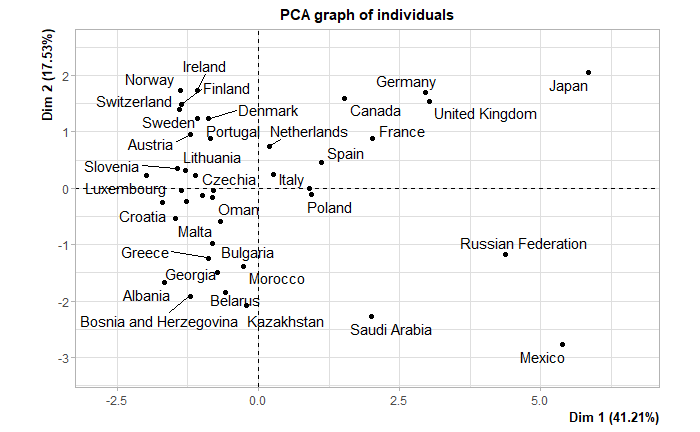

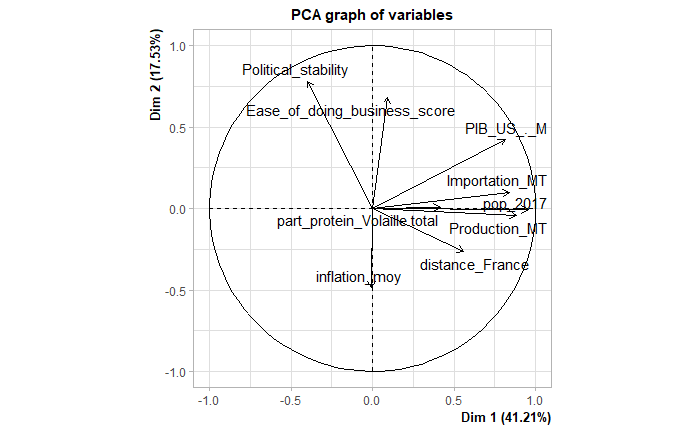

```r
res.pca <- PCA(donnees.pca, scale.unit = TRUE, ncp = 3, graph = TRUE)
```

## éboulis des valeurs propres

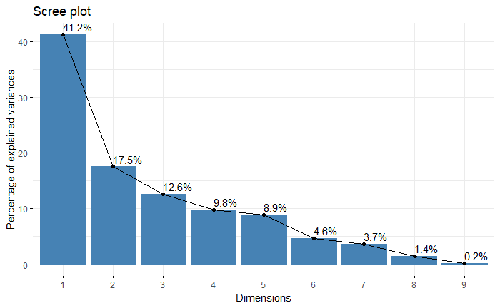

```r
library(factoextra)
fviz_eig(res.pca, addlabels = TRUE)
```

## qualité de la représentation

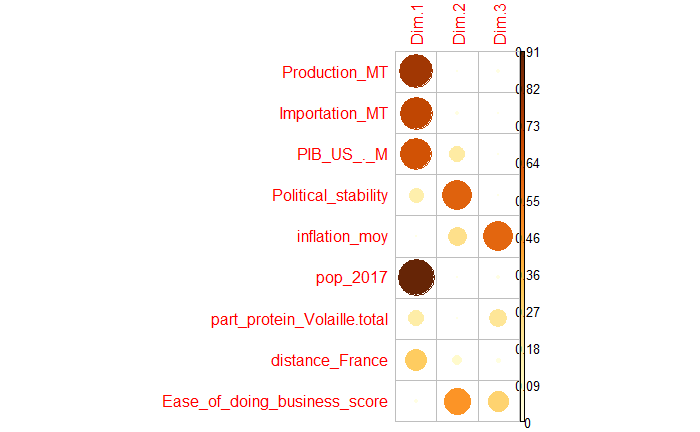

```r
corrplot(res.pca$var$cos2, is.corr = FALSE)
```

## cercle des corrélations

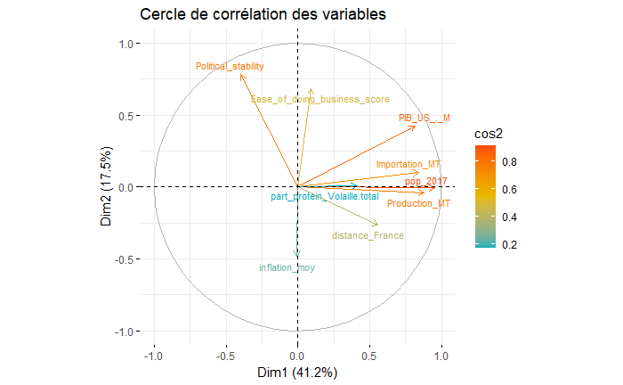

```r
fviz_pca_var(res.pca,
             title='Cercle de corrélation des variables',
             col.var = "cos2",
             gradient.cols =  c("#00AFBB", "#E7B800", "#FC4E07"),
             #alpha.var = "cos2",
             geom=c('arrow', 'text'),
             labelsize = 3,
             repel = TRUE
)
```

## nuages des individus

```r
# on créé la figure
figure = fviz_pca_ind(res.pca,
             geom=c("text", 'point'),
             labelsize=3,
             alpha.ind="cos2",
             #pointsize='5',
             repel = TRUE,
             mean.point = FALSE
)

# On l'enregistre
png(file="../assets/resultats/acp_onSelection_individual.png",width=1800,height=750)

print(figure)
dev.off() # Close the pdf device
```

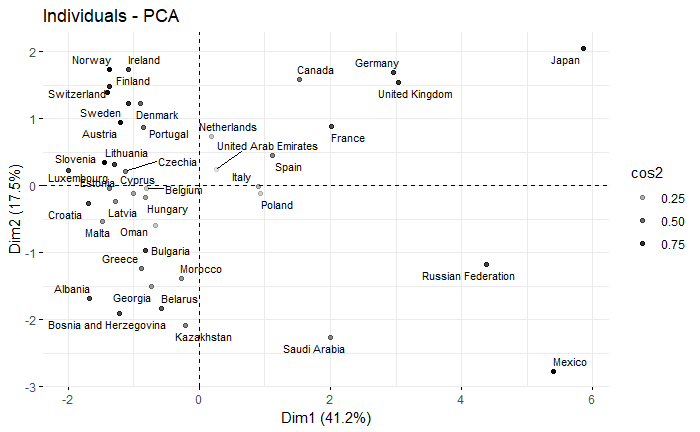

```r
# on l'affiche
figure
```

### ACP avec Factominer

```r
library('FactoMineR') # ACP
library('Factoshiny') # ACP
```

```r
# res.PCA <- Factoshiny(donnees.pca)
```

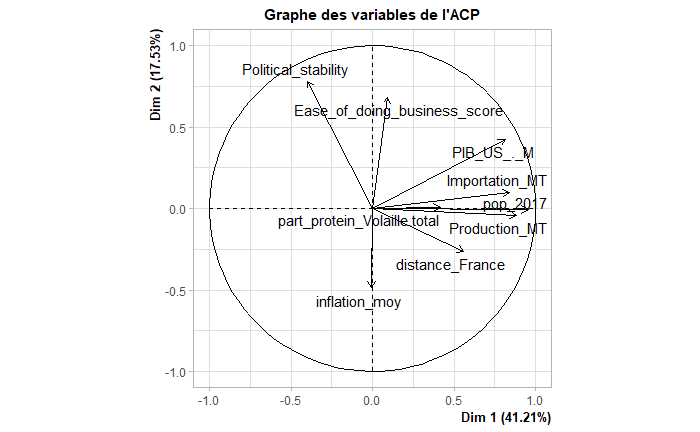

```r
res.PCA<-PCA(donnees.pca,graph=FALSE)
plot.PCA(res.PCA,choix='var',title="Graphe des variables de l'ACP")
```

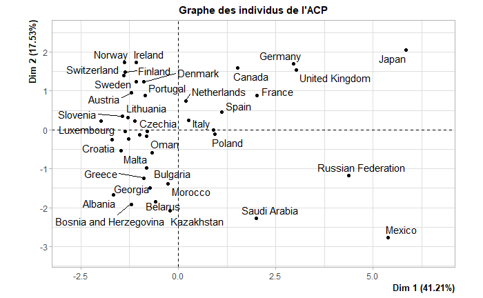

```r
plot.PCA(res.PCA,title="Graphe des individus de l'ACP")
```

```r
# PCAshiny(donnees.pca)
```

Retour aux données…

```r
retourDonnee = donnees.Pays
retourDonnee = subset(retourDonnee, retourDonnee$cluster == 5)
retourDonnee <- retourDonnee[,c(-11,-12,-13)]

retourDonnee[c('France',
               'Netherlands',
               'Germany',
               'Spain',
               'Canada',
               'United Kingdom',
               'Italy',
               'Japan',
               'Poland'),]
```

|  | Country | Production_MT | Importation_MT | PIB_US_._M | Political_stability | inflation_moy | pop_2017 | part_protein_Volaille.total | distance_France | Ease_of_doing_business_score |
| --- | --- | --- | --- | --- | --- | --- | --- | --- | --- | --- |
| France | France | 1750 | 506 | 2595151.0 | 0.28 | 1.0885883 | 64842509 | 7.93 | 278.1876 | 76.20156 |
| Netherlands | Netherlands | 1100 | 608 | 833869.6 | 0.92 | 2.6643255 | 17021347 | 6.58 | 427.9169 | 75.29032 |
| Germany | Germany | 1514 | 842 | 3690849.2 | 0.59 | 2.7624968 | 82658409 | 7.10 | 439.8984 | 79.42867 |
| Spain | Spain | 1515 | 205 | 1312539.3 | 0.28 | 1.2314017 | 46647428 | 11.61 | 1054.6560 | 77.63075 |
| Canada | Canada | 1417 | 182 | 1649519.0 | 1.10 | -0.9752023 | 36732095 | 13.21 | 6004.6450 | 80.04017 |
| United Kingdom | United Kingdom | 1814 | 779 | 2699016.7 | 0.33 | 2.2611514 | 66727461 | 13.40 | 342.9475 | 83.34037 |
| Italy | Italy | 1315 | 97 | 1961796.2 | 0.31 | 1.8801686 | 60673701 | 7.47 | 1109.9010 | 71.82263 |
| Japan | Japan | 2215 | 1069 | 4930837.4 | 1.11 | 0.6982633 | 127502725 | 8.34 | 9725.6290 | 78.27679 |
| Poland | Poland | 2351 | 55 | 526504.2 | 0.52 | 4.3149003 | 37953180 | 13.34 | 1368.1780 | 77.64919 |

```r
NA
```

### Carte repartition des groupes issus du kmeans

```r
#library(maptools)
data(wrld_simpl)
my_map <- wrld_simpl
```

```r
png(file="../assets/resultats/MAP_resultatFinal.png",width=1800,height=750)
country_colors <- setNames(rep("white", length(my_map$NAME)), my_map$NAME)

country_colors[c('France',
               'Netherlands',
               'Spain',
               'Germany',
               'Canada',
               'United Kingdom',
               'Italy',
               'Japan',
               'Poland'
               )] <- c('orange') # cluster 1

plot(my_map, col = country_colors)
title("Les pays à fort potentiel")

legend(x='bottomright', border = "black",title = 'les clusters',cex=2 ,legend = c( "Pays propices à l'export"),fill = c('green'))
```

Nettoyage environnement

```r
rm(wrld_simpl,my_map,country_colors)
```